# Fibonnaci Problem

Given the equation to generate the numbers we can define

```python
import matplotlib.pylab as plt
```

```python
def fib(n):
    if n==0:
        return 0
    if n==1:
        return 1
    else:
        return fib(n-1)+fib(n-2)
```

for measure the time we can import time just as indicated

```python
import time
n=35
times=[]
for i in range(n):
    init=time.time()
    fib(i)
    difference_time=float(time.time()-init)
    times.append(difference_time)
```

Now we plot the times our code takes to run

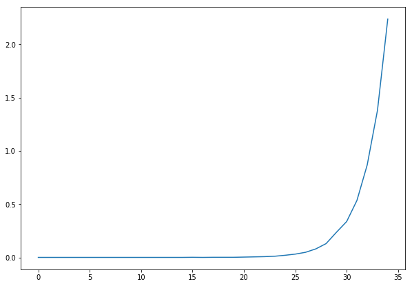

```python
plt.figure(figsize=(10,7))
plt.plot(range(n),times)
plt.show()
```

Now we define our new function which computes the Fibonacci numbers using dynamic programming ( it means that we use the previous results, being the main reason why it is that fast)

```python
def fib_fast(n):
    if n==0:
        return 0
    elif n==1:
        return 1
    elif n>0:
        f_n_1=fib(1)
        f_n_2=fib(0)
        f_n=0
        for i in range(n-1):
            f_n = (f_n_1+f_n_2)
            f_n_2=f_n_1
            f_n_1=f_n
        return f_n
```

```python
n=50
times=[]
for i in range(n):
    init=time.time()
    fib_fast(i)
    difference_time=float(time.time()-init)
    times.append(difference_time)
```

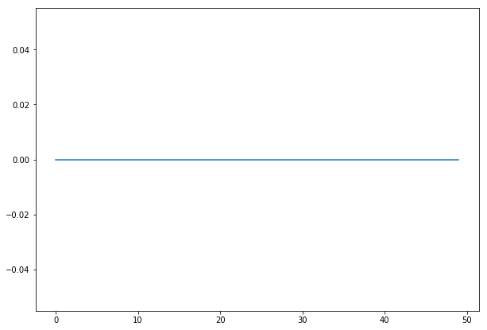

```python
plt.figure(figsize=(10,7))
plt.plot(range(n),times)
plt.show()
```

So here we can see that this code is fast, it is that fast that the compute can not perceive the difference to see a bigger difference we can compute the Fibonacci numbers between 100000 and 200000 in steps of 10000

```python
import time
n=200000
times=[]
for i in range(100000,n,10000):
    init=time.time()
    fib_fast(i)
    difference_time=float(time.time()-init)
    times.append(difference_time)
```

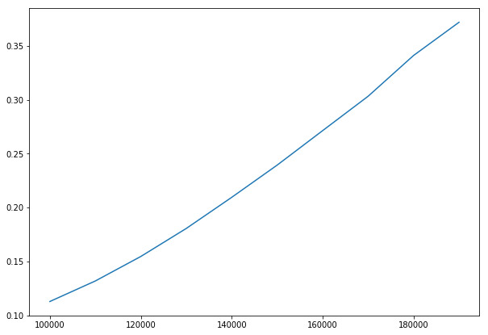

```python
plt.figure(figsize=(10,7))
plt.plot(range(100000,n,10000),times)
plt.show()
```

To check our code is working we can compute the ratio of the numbers, we are going to calculate the first 1000 we avoid the first since it is zero

```python
n=1000
numbers=[]
for i in range(n):
    numbers.append(fib_fast(i))
ratio=[]
for i in range(10,len(numbers)-1):
    ratio.append(numbers[i+1]/numbers[i])
```

```
(1.6, 1.63)
```

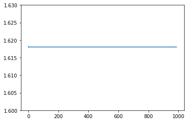

```python
plt.plot(ratio)
plt.ylim(1.6,1.63)
```

As we can see it is giving us the value of 1.6. it is not coincidence since that ratio has to give us the golden mean. $$ \frac{1+\sqrt{5}}{2}\approx 1.618033988 $$ to see this let's plots the differences.

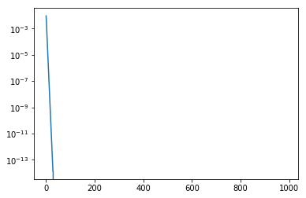

```python
import math
diferences=[]
golden_mean=(1+math.sqrt(5))*0.5
for i in range(len(ratio)):
    diferences.append(abs(ratio[i]-golden_mean)/golden_mean * 100)
plt.plot(diferences)
plt.yscale("log")
```

# Bonus

```python
def fib(n):
    if n==0:
        return 0
    if n==1:
        return 1
    else:
        return fib(n+2)-fib(n+1)
```

```python
for i in range(1,10):
    print("Fibonnaci of -{}, F(-{})".format(i,i),fib(-i))
```

```
Fibonnaci of -1, F(-1) 1
Fibonnaci of -2, F(-2) -1
Fibonnaci of -3, F(-3) 2
Fibonnaci of -4, F(-4) -3
Fibonnaci of -5, F(-5) 5
Fibonnaci of -6, F(-6) -8
Fibonnaci of -7, F(-7) 13
Fibonnaci of -8, F(-8) -21
Fibonnaci of -9, F(-9) 34
```